# Informe_PG2

S2 Niveles de Estrés y Ansiedad

06-05-2022

```r
library("pacman")
```

```r
p_load(readr, dplyr, corrplot, ggplot2, tidyr, lubridate, scales, multimode, stringr,ggmosaic,car,DescTools, gt,ggthemes)
```

# Introducción

### Niveles de ansiedad y estrés de los alumnos UTEC en distintas épocas del ciclo.

## Relevancia y Antecedentes

**Relevancia**

A lo largo de la vida de una persona, esta se ha de enfrentar a distintas situaciones de gran dificultad. En este sentido, algunos indicadores y/o síntomas, tanto físicos cómo mentales, nos permiten conocer su estado de salud. Uno de los casos más comunes son los altos niveles de estrés y ansiedad que puede presentar una persona, tanto junto cómo por separado, ocasionando un déficit en cualquier tipo de rendimiento en su vida. Es así que es de gran relevancia tener un sondeo constante de estos niveles para poder tener un mejor desempeño y salud.

**Antecedente**

El primer motivo para realizar nuestro proyecto es saber cuántos alumnos del ciclo actual 2022-2 sufren con estres y/o ansiedad en diversas fechas a lo largo del ciclo presente. Se justifica la elección de este antecedente debido a la gran recurrencia a decir las frases, “Que estrés me da la universidad”, “Estoy demasiado ansioso por este examen” en los alumnos. Entonces decidimos hacer el proyecto a base de eso, sabiendo que el espacio de estudio es muy diverso y de gran extensión.

## *Objetivos del estudio*

**Objetivo 1**

Al finalizar este estudio esperamos determinar el nivel de estrés y ansiedad en estudiantes de utec. En base a este informe estudiado esperamos poder sugerir ayudas como los couseling en la misma universidad,o datos sobre psicólogos para poder manejar mejor este tema e ideas de motivación hacia los estudiantes,ya que esta situación de por sí ya es bastante complicada.

**Objetivo 2**

Al terminar el proyecto luego de trabajar con los datos obtenidos mediante una encuesta podemos determinar la cantidad de alumnos que sufre de ansiedad y estrés en una determinada fecha y poder explicarla mediante diveresos datos estadísticos.

**Objetivo 3**

Con la ayuda de la herramienta probabilistica, diferenciar el grado de estrés y ansiedad que sufren los alumnos, y si es más intenso en ciclos inferiores o superiores, si dependen del género o está influenciado por los espacios de estudio alrededor de la universidad.

# Datos

## Proceso de recoleccion de datos

Los datos de la recolección fueron llenados el día 21 de setiembre, completando el mínimo de encuestas posibles(200). Mediante una separación por parte de los integrantes del grupo en los diversos pisos de la universidad fuimos encuestando a grupos de personas dandole un incentivo para que rellenen la encuesta en su totalidad.

**Previsualización de lo que fue forms**

[figure not shown]

Enlace del Forms

## Poblacion, muestra y muestreo

- **Población de estudio:** Alumnos matriculado en la universidad utec, del ciclo 2022-2.
- **Unidad muestral:** Encuesta completada por un alumno mediante un código Qr que un encuestador le proporcionó.
- **Muestreo:** Muestreo por conveniencia, nos basamos en sujetos(alumnos) disponibles que estaban distrayendose, terminando de comer, conversando o caminando por el campus.Al momento de encuestarlos siempre haciamos la pregunta de “¿Estás ocupado?, ¿te puedo pedir un favor?. Al estar dentro del campus, nosotros elegimos quienes serán nuestros sujetos de prueba y nos acercamos a ellos para poder encuestarlos. Al final del recorrido contamos con un total de 226 observaciones que recogimos mediante el forms hecho.

## Variables

| Variable | Tipo de variable | Descripción |
| --- | --- | --- |
| `ciclo` | Categórica Nominal | Toma valores del número de ciclo presente(colocando solo números): {1,2,3,4,5,6,7,8,9,10}. Representa él ciclo en el que se encuentra. |
| `edad` | Numérica Discreta | Toma valores del intervalo [16, 40]. Representa la edad de cada estudiante |
| `carrera` | Categórica nominal | Toma valores de las carreras que se encuentran en la universidad(colocando sus nombres): {Bioingeniería,Ingeniería industrial,Ingeniería Mecánica,Ingeniería Química,Ciencia de la Computación,Ingenierí… |
| `genero` | Categórica nominal | Toma valores lógicos `Masculino` o `Femenino`. Representa el género del estudiante |
| `cursos` | Numérica Discreta | Toma valores en el intervalo [2, 8]. Representa el número de cursos que lleva el estudiante |
| `anxiety_before_ex` | Categórica ordinaria | Define el nivel de ansiedad del estudiante antes del periodo de evaluaciones(en una horquilla del 1 al 10) |
| `anxiety_after_ex` | Numérica Discreta | Define el nivel de ansiedad del estudiante después del periodo de evaluaciones(en una horquilla del 1 al 10) |
| `cause_ansiedad_U` | Categórica nominal | Toma valores los posibles factores que causen ansiedad: {Demasiadas personas,Que no respeten tu espacio personal,Mucho ruido,Mal funcionamiento de los servicios (ascensores, reconocimiento facial),No … |
| `help_ansiedad` | Categórica nominal | Toma valores lógicos `si` o `no`. Representa si el estudiante ha pedido alguna ayuda sobre este tema . |
| `stress_before_ex` | Numérica Discreta | Define el nivel de estrés del estudiante antes del periodo de evaluaciones(en una horquilla del 1 al 10) |
| `stress_after_ex` | Numérica Discreta | Define el nivel de estrés del estudiante después del periodo de evaluaciones(en una horquilla del 1 al 10). |
| `cause_estres_U` | Categórica ordinal | Toma valores de escala de frecuencia en que se presentan los síntomas de estrés (tomando solo las palabras clave de frecuencia en que se presenta este síntoma): {Nunca,Casi nunca,De vez en cuando,A me… |
| `help_estres` | Categórica nominal | Toma valores lógicos `si` o `no`. Representa si el estudiante ha pedido alguna ayuda sobre este tema . |
| `tiempo_de_estudio` | Numérica Continua | Variable aleatoria que representa el tiempo que emplean los alumnos de utec para estudiar la día. . |

## Limpieza de datos

### Politica de manejo de datos faltantes

Respecto a los datos faltantes o datos is.na, no hubo algunos. La explicación es que mediante una configuración en el formulario hicimos que TODAS las preguntas sean obligatorias y no podías pasar página si no completabas alguna.

### Política de resolución de errores

Hubo un solo caso de resolución de error, un encuestado puso un su edad como número decimal “16.5”, en este caso se aproximó a 17 y quedó como si nada hubiera pasado. Como anteriormente mencionado, no hubo datos faltantes, NA’s o datos no enteros ya que en el mismo forms se especificaba la manera de llenado y saltaba un error si te querías pasar de listo. Por ejemplo en la edad nos fijamos previamente el intervalo de edad normal de un estudiante sería desde los 15 hasta los 30 años, por lo que solo aceptaba valores entre esos dos.

```r
DP5<- read_csv("Niveles de estres y ansiedad.csv")
```

1. Importamos la data y cambiamos el nombre a las variables para que sean mas accesibles.

```r
DP5 <- rename(DP5,Ciclo= 'Ciclo cursante', Carrera= '¿Qué carrera estudias?' , Genero= 'Género' , Cursos= '¿Cuántos cursos lleva?' ,tiempo="¿Cuanto tiempo en horas estudia al día?", anxiety_before_ex= 'Cuál considera que ha sido su nivel de ansiedad, en promedio, antes de rendir cualquier evaluación' , anxiety_after_ex= 'Cuál considera que ha sido su nivel de ansiedad, en promedio, después de rendir cualquier evaluación' , time_mayor_anxiety= '¿Cuáles han sido sus épocas de mayor ansiedad?' , ESF_angustia= 'Escala de síntomas físicos [Sensación de angustia o aprensión]' , ESF_intranquilidad= 'Escala de síntomas físicos [Dificultad para estar quieto, intranquilidad]' , ESF_palpitaciones='Escala de síntomas físicos [Aumento de frecuencia cardiaca (palpitaciones) sin enfermedad conocida que lo justifique]', ESF_fatiga='Escala de síntomas físicos [Fatiga, especialmente importante al final del día]', ESF_sueño_alterado= 'Escala de síntomas físicos [Alteraciones en el sueño; tardas en quedarte dormido, te despiertas varias veces o despiertas antes de lo previsto]',  ESF_tension_muscular= 'Escala de síntomas físicos [Sensación de tensión muscular que puede ir acompañada de dolor en determinadas partes de tu cuerpo (cuello, espalda, cabeza, etcétera)]', ESC_dificil_concentracion='Escala de síntomas cognitivos [Dificultad para concentrarte]' , ESC_bloqueo_mental= 'Escala de síntomas cognitivos [Sensación de bloqueo mental]' , ESC_acontencimientos_negativos= 'Escala de síntomas cognitivos [Anticipación de acontecimientos negativos. Catastrofismo]', ESC_falta_memoria= 'Escala de síntomas cognitivos [Falta de memoria (dificultad para recordar cosas)]' , ESC_pensamientos_desagradables= 'Escala de síntomas cognitivos [Pensamientos o imágenes desagradables]', ESC_dificultad_decisiones= 'Escala de síntomas cognitivos [Dificultad para tomar decisiones (por ejemplo “das vueltas a la cabeza” sin llegar a decidirte)]', ESCCA_comer_beber= 'Escala de síntomas comportamentales para combatir la ansiedad [Fumas, comes o bebes para calmar tu ansiedad]' ,  ESCCA_escapar= 'Escala de síntomas comportamentales para combatir la ansiedad [Evitas o escapas de determinadas situaciones]',  ESCCA_movimientos_repetitivos='Escala de síntomas comportamentales para combatir la ansiedad [Haces movimientos repetitivos (tocarte el pelo, temblor de piernas)]' , ESCCA_moverse_mucho= 'Escala de síntomas comportamentales para combatir la ansiedad [Te mueves más de lo habitual]' , ESCCA_movimientos_torpe='Escala de síntomas comportamentales para combatir la ansiedad [Movimientos torpes (por ejemplo se te caen las cosas)]' , ESCCA_llanto= 'Escala de síntomas comportamentales para combatir la ansiedad [Llanto para aliviar tu malestar]',cause_ansiedad_U='¿Algo dentro de la universidad te cause demasiada ansiedad?', help_ansiedad='Ha buscado algún tipo de ayuda sobre cómo tratar la ansiedad')
```

```r
DP5<-rename(DP5,stress_before_ex='Cuál considera que ha sido su nivel de estrés, en promedio, antes de rendir cualquier evaluación',stress_after_ex='Cuál considera que ha sido su nivel de estrés, en promedio, después de rendir cualquier evaluación',time_mayor_stress='Cuáles han sido sus épocas de mayor estrés',ESFCE_cansancio='Escala de síntomas físicos y cognitivos  [Te sientes cansado/a]',ESFCE_relajarse='Escala de síntomas físicos y cognitivos  [Se te hace difícil relajarte o sentirte tranquilo/a]',ESFCE_dificultad_tomar_decisiones='Escala de síntomas físicos y cognitivos  [Se te hace difícil tomar decisiones]',ESFCE_pensar_claridad='Escala de síntomas físicos y cognitivos  [Tienes problemas para pensar con claridad]',ESFCE_pensar_problemas='Escala de síntomas físicos y cognitivos  [Piensas en tus problemas una y otra vez durante el día]',ESFCE_comer_demasiado='Escala de síntomas físicos y cognitivos  [Comes demasiado o muy poco]',ESFCE__dificultad_sueño='Escala de síntomas físicos y cognitivos  [Dificultad para conciliar el sueño]',ESFCE_dolor_cuerpo='Escala de síntomas físicos y cognitivos  [Dolor de espalda,cuello u otro dolor relacionado con la tensión]',ESFCE_caefeina_nicotina='Escala de síntomas físicos y cognitivos  [Uso más seguido de cafeína o nicotina de lo habitual]',ESFCE_tics_nervous='Escala de síntomas físicos y cognitivos  [Tics nerviosos]',ESFCE_dolor_estomacal='Escala de síntomas físicos y cognitivos  [Malestar estomacal]',ESFCE_irritacion='Escala de síntomas físicos y cognitivos  [Irritación con facilidad]',ESFCE_cambios_humor='Escala de síntomas físicos y cognitivos  [Cambios de humor y sensibilidad]',ESFCE_dificultad_concentrarse='Escala de síntomas físicos y cognitivos  [Dificultad al concentrarse]',ESFCE_alcohol_droga='Escala de síntomas físicos y cognitivos  [Uso de alcohol o drogas para afrontar problemas]',ESFCE_disminuye_desempeño_U='Escala de síntomas físicos y cognitivos  [Tu desempeño ha disminuido y presentas problemas para completar tus tareas]',ESFCE_sudar_palpitar='Escala de síntomas físicos y cognitivos  [Tendencias a sudar o palpitaciones]',ESFCE_levantarse_tarde='Escala de síntomas físicos y cognitivos  [Tentaciones fuertes de no levantarse por la mañana]',FS_no_afrontar_actividades='Evalúe con que frecuencia siente cada uno de los siguientes síntomas [¿Con qué frecuencia ha sentido que no podía afrontar todas las cosas que tenía que hacer?]',FS_todo_controlado='Evalúe con que frecuencia siente cada uno de los siguientes síntomas [¿Con qué frecuencia se ha sentido al control de todo?]',FS_enfadado_fueradecontrol='Evalúe con que frecuencia siente cada uno de los siguientes síntomas [¿Con qué frecuencia ha estado enfadado porque las cosas que le han ocurrido estaban fuera de su control?]',FS_controlar_tiempo='Evalúe con que frecuencia siente cada uno de los siguientes síntomas [¿Con qué frecuencia ha podido controlar la forma de pasar el tiempo?]',FS_dificultades_acumulan='Evalúe con que frecuencia siente cada uno de los siguientes síntomas [¿Con qué frecuencia ha sentido que las dificultades se acumulan tanto que no puede superarlas?]',FS_afectado_imprevistos='Evalúe con que frecuencia siente cada uno de los siguientes síntomas [¿Con qué frecuencia ha estado afectado por algo que ha ocurrido inesperadamente?]',FS_manejar_problemas_vida='Evalúe con que frecuencia siente cada uno de los siguientes síntomas [¿Con qué frecuencia ha manejado con éxito los pequeños problemas irritantes de la vida?]',FS_afrontar_cambios_vida='Evalúe con que frecuencia siente cada uno de los siguientes síntomas [¿Con qué frecuencia ha sentido que ha afrontado efectivamente los cambios importantes que han estado ocurriendo en su vida?]',cause_estres_U='¿Algo dentro de la universidad que te cause estrés?',help_estres='Ha buscado algún tipo de ayuda sobre cómo tratar el estrés')
```

2. Pareciera haber datos atípicos en el boxplot, por ello usamos unique para ver a detalle todas las posibles respuestas que llenaron los encuestados.

```r
unique(DP5$Edad)
```

```
##  [1] 18.0 19.0 20.0 17.0 23.0 21.0 22.0 24.0 25.0 16.5
```

3. Reemplazamos uno de los datos por uno más válido El dato 16.5 no es valido para la variable Edad, por ello tendremos que reemplazarlo por el dato más obvio.

```r
DP5$Edad=str_replace(DP5$Edad,"16.5","17")
```

4. Comprobamos el cambio

```r
unique(DP5$Edad)
```

```
## [1] "18" "19" "20" "17" "23" "21" "22" "24" "25"
```

5. Eliminamos variables inservibles:

```r
DP5 %>% select(-1)->DP5
```

```r
write_csv(DP5, "DataLimpia.csv")
```

Dataframes

```r
DL<- read_csv("DataLimpia.csv")
DD<-DL[complete.cases(DL),]
```

# Análisis de Datos

Mediante el análisis de datos podemos hallar descriptores para un uso próximo en nuestro informe y dar validez a nuestras afirmaciones.

## Descriptores de Posición, Descriptores de Dispersión y Descriptores Numéricos.

**Descriptores de posición:** informan sobre la ubicación de los datos.

1. Promedio: los datos están alrededor del promedio, el promedio es el centro de masa de los datos.•Mediana: al menos la mitad de los datos son mayores o iguales a la mediana menores o iguales a la mediana. La mediana, en general, no es única.
2. Cuantil q %: al menos el q % de los datos es menor o igual al cuantil q %, al menos el (1-q) % de los datos es mayor o igual que el cuantil q %. El cuantil q %, en general no es único. La mediana es el cuantil 50 % o el segundo cuartil.
3. Mínimo: el valor del menor dato. Corresponde al cuantil 0 %.
4. Máximo: el valor del mayor dato. Corresponde al cuantil 100 %.
5. Moda: el o los datos que más se repiten.

**Descriptores de dispersión:** informan sobre el nivel de variación de los datos.

1. Rango: diferencia entre el máximo y el mínimo, representa el máximo observado de variación de los datos. Rango grande, dispersión alta, rango pequeño, dispersión baja.
2. Varianza: promedio de los cuadrados de la diferencia el dato y el promedio. Poblacional o muestral.
3. Desviación estándar: raíz cuadrada de la varianza. Poblacional o muestral.
4. Rango intercuartil: diferencia entre el tercer y el primer cuartil.

### Analisis de la variable Edad

Justificación:

**Edad promedio**

```r
mean(DL$Edad)
```

```
## [1] 19.02655
```

**Mediana de edad**

```r
median(DL$Edad)
```

```
## [1] 19
```

**Edad más recogida o más frecuente (moda)**

```r
Mode(DL$Edad)
```

```
## [1] 18
## attr(,"freq")
## [1] 65
```

**Desviacion estandar**

```r
sd(DL$Edad)
```

```
## [1] 1.605325
```

**Cauntil q%**

```r
quantile(DL$Edad,0.1)
```

```
## 10%
##  17
```

```r
quantile(DL$Edad,0.9)
```

```
## 90%
##  21
```

**Rango intercuartil de la variable edad**

```r
IQR(DL$Edad)
```

```
## [1] 2
```

**Varianza de la varaible edad**

```r
var(DL$Edad)
```

```
## [1] 2.57707
```

### Análisis variable Cursos(cantidad de cursos)

Justificación:

**Mediana de cantidad de cursos llevado**

```r
median(DL$Cursos)
```

```
## [1] 6
```

**Cantidad de cursos más frecuente (moda)**

```r
Mode(DL$Cursos)
```

```
## [1] 6
## attr(,"freq")
## [1] 115
```

**Rango intercuartil**

```r
IQR(DL$Cursos)
```

```
## [1] 1
```

**Desviacion estandar**

```r
sd(DL$Cursos)
```

```
## [1] 0.9264389
```

**Varianza**

```r
var(DL$Cursos)
```

```
## [1] 0.8582891
```

### Análisis variable anxiety_before_ex

Justificación:

- Se utilizó la variable anxiety_before_ex ya que esta variable define el nivel de ansiedad del estudiante antes de tener una evaluación y toma valores en una horquilla del 1 al 10.

**Promedio de nivel de ansiedad de los alumnos antes de exámenes**

```r
mean(DL$anxiety_before_ex)
```

```
## [1] 7.336283
```

**Mediana de nivel de ansiedad antes de exámenes**

```r
median(DL$anxiety_before_ex)
```

```
## [1] 8
```

**Cauntil q%**

```r
quantile(DL$anxiety_before_ex,0.1)
```

```
## 10%
## 4.5
```

```r
quantile(DL$anxiety_before_ex,0.9)
```

```
## 90%
##  10
```

**Rango intercuartil de la variable anxiety_before_ex**

```r
IQR(DL$anxiety_before_ex)
```

```
## [1] 3
```

**Desviación estandar**

```r
sd(DL$anxiety_before_ex)
```

```
## [1] 2.050954
```

**Varianza**

```r
var(DL$anxiety_before_ex)
```

```
## [1] 4.206411
```

### Análisis variable anxiety_after_ex

Justificación:

- Se utilizó la variable anxiety_after_ex ya que esta variable representa el nivel de ansiedad del estudiante después de tener una evaluación y toma valores en una horquilla del 1 al 10.

**Promedio de nivel de ansiedad de los alumnos después de exámenes**

```r
mean(DL$anxiety_after_ex)
```

```
## [1] 6.221239
```

**Mediana de nivel de ansiedad después de exámenes**

```r
median(DL$anxiety_after_ex)
```

```
## [1] 6
```

**Cauntil q%**

```r
quantile(DL$anxiety_after_ex,0.1)
```

```
## 10%
##   3
```

```r
quantile(DL$anxiety_after_ex,0.9)
```

```
## 90%
##  10
```

**Rango intercuartil de la variable anxiety_after_ex**

```r
IQR(DL$anxiety_after_ex)
```

```
## [1] 4
```

**Desviación estandar**

```r
sd(DL$anxiety_after_ex)
```

```
## [1] 2.527131
```

**Varianza**

```r
var(DL$anxiety_after_ex)
```

```
## [1] 6.386391
```

### Análisis variable stress_before_ex

Justificación:

- Se utilizó la variable stress_before_ex ya que esta variable define el nivel de estrés del estudiante antes de tener una evaluación y toma valores en un intervalo del 1 al 10.

**Promedio de nivel de estrés de los alumnos antes de exámenes**

```r
mean(DL$stress_before_ex)
```

```
## [1] 7.349558
```

**Mediana de nivel de estrés antes de exámenes**

```r
median(DL$stress_before_ex)
```

```
## [1] 8
```

**Cauntil q%**

```r
quantile(DL$stress_before_ex,0.1)
```

```
## 10%
## 4.5
```

```r
quantile(DL$stress_before_ex,0.9)
```

```
## 90%
##  10
```

**Rango intercuartil de la variable stress_before_ex:**

```r
IQR(DL$stress_before_ex)
```

```
## [1] 3
```

**Desviación estandar**

```r
sd(DL$stress_before_ex)
```

```
## [1] 2.038938
```

**Varianza**

```r
var(DL$stress_before_ex)
```

```
## [1] 4.157266
```

### Análisis variable stress_after_ex

Justificación:

- Se utilizó la variable stress_after_ex ya que esta variable define el nivel de estrés del estudiante después de tener una evaluación y toma valores en un intervalo del 1 al 10.

**Promedio de nivel de estrés de los alumnos después de exámenes**

```r
mean(DL$stress_after_ex)
```

```
## [1] 6.154867
```

**Mediana de nivel de estrés después de exámenes**

```r
median(DL$stress_after_ex)
```

```
## [1] 7
```

**Cauntil q%**

```r
quantile(DL$stress_after_ex,0.1)
```

```
## 10%
##   2
```

```r
quantile(DL$stress_after_ex,0.9)
```

```
## 90%
## 9.5
```

**Rango intercuartil de la variable stress_after_ex**

```r
IQR(DL$stress_after_ex)
```

```
## [1] 4
```

**Desviación estandar**

```r
sd(DL$stress_after_ex)
```

```
## [1] 2.639511
```

**Varianza**

```r
var(DL$stress_after_ex)
```

```
## [1] 6.967021
```

### Correlación y covarianza entre la variables estres antes del examen y el número de cursos llevados:

```r
cor(DL$stress_before_ex,DL$Cursos)
```

```
## [1] -0.1052334
```

```r
cov(DL$stress_before_ex,DL$Cursos)
```

```
## [1] -0.1987807
```

### Correlación y covarianza entre la variables estres después del examen y el número de cursos llevados:

```r
cor(DL$stress_after_ex,DL$Cursos)
```

```
## [1] -0.02547733
```

```r
cov(DL$stress_after_ex,DL$Cursos)
```

```
## [1] -0.06230088
```

## Tablas y Descriptores Gráficos de interacción:

Utilizando algunos valores de la parte de “Analisis de datos” como el promedio, la mediana y la moda podemos realizar algunos gráficos y a partir de estos concluir con unos comentarios lo que significa cada uno.

### Tablas Simples:

```r
DL %>% group_by(Cursos) %>% summarise("frecuencia absoluta"=n())
```

| Cursos | frecuencia absoluta |
| --- | --- |
| 3 | 2 |
| 4 | 21 |
| 5 | 52 |
| 6 | 115 |
| 7 | 30 |
| 8 | 6 |

Tabla 1: La mayoría de los alumnos llevan 6 cursos.

```r
DL %>% group_by(Edad) %>% summarise("frecuencia absoluta"=n())
```

| Edad | frecuencia absoluta |
| --- | --- |
| 17 | 36 |
| 18 | 65 |
| 19 | 50 |
| 20 | 36 |
| 21 | 22 |
| 22 | 9 |
| 23 | 5 |
| 24 | 2 |
| 25 | 1 |

Tabla 2: Según la tabla, la mayoría de los alumnos tienen 18 años.

### Tablas Dobles

```r
tabla1<-select(DL,3,12)
table(tabla1)
```

```
##                                      ESF_palpitaciones
## Carrera                               A menudo Casi todos los días
##   Administración y Negocios Digitales        0                   0
##   Bioingeniería                              2                   4
##   Ciencia de Datos                           1                   2
##   Ciencia de la computación                  8                   2
##   Ingeniería Ambiental                       5                   1
##   Ingeniería Civil                           9                   6
##   Ingeniería de la Energía                   2                   0
##   Ingeniería Electrónica                     2                   0
##   Ingeniería Industrial                     13                   4
##   Ingeniería Mecánica                        1                   1
##   Ingeniería Mecatrónica                     4                   1
##   Ingeniería Química                         3                   0
##                                      ESF_palpitaciones
## Carrera                               En alguna ocasión Nunca
##   Administración y Negocios Digitales                 2     3
##   Bioingeniería                                       6     3
##   Ciencia de Datos                                    0     2
##   Ciencia de la computación                          11     9
##   Ingeniería Ambiental                                4     3
##   Ingeniería Civil                                   15    14
##   Ingeniería de la Energía                            1     1
##   Ingeniería Electrónica                              3     0
##   Ingeniería Industrial                              13    18
##   Ingeniería Mecánica                                 9     2
##   Ingeniería Mecatrónica                             18    13
##   Ingeniería Química                                  3     2
```

```r
tabla2<-select(DL,5,40)
table(tabla2)
```

```
##       ESFCE_dolor_cuerpo
## Cursos Aveces Frecuentemente Nunca Seguido Siempre
##      3      0              1     0       1       0
##      4      4              7     2       4       3
##      5     15              6     8      15       7
##      6     43             12    10      32      15
##      7      6              3     7       6       7
##      8      3              2     1       0       0
```

### Tablas desagregadas:

```r
tabla4<-select(DL,4,26,28)
table(tabla4)
```

```
## , , cause_ansiedad_U = Demasiadas personas
##
##            ESCCA_movimientos_torpe
## Genero      A menudo Casi todos los días En alguna ocasión Nunca
##   Femenino         3                   2                 3     1
##   Masculino        7                   3                 6     5
##
## , , cause_ansiedad_U = Mal funcionamiento de los servicios (ascensores, reconocimiento facial)
##
##            ESCCA_movimientos_torpe
## Genero      A menudo Casi todos los días En alguna ocasión Nunca
##   Femenino         2                   0                 1     4
##   Masculino        6                   1                 8     4
##
## , , cause_ansiedad_U = Mucha ventilación
##
##            ESCCA_movimientos_torpe
## Genero      A menudo Casi todos los días En alguna ocasión Nunca
##   Femenino         2                   0                 5     2
##   Masculino        2                   1                 1     0
##
## , , cause_ansiedad_U = Mucho ruido
##
##            ESCCA_movimientos_torpe
## Genero      A menudo Casi todos los días En alguna ocasión Nunca
##   Femenino         2                   4                 1     1
##   Masculino        9                   1                13     8
##
## , , cause_ansiedad_U = No tener espacio para estudiar
##
##            ESCCA_movimientos_torpe
## Genero      A menudo Casi todos los días En alguna ocasión Nunca
##   Femenino         6                   2                16     9
##   Masculino        4                   2                29    25
##
## , , cause_ansiedad_U = Que no respeten tu espacio personal
##
##            ESCCA_movimientos_torpe
## Genero      A menudo Casi todos los días En alguna ocasión Nunca
##   Femenino         4                   1                 2     4
##   Masculino        4                   1                 6     3
```

```r
tabla6<-select(DL,2,34,4)
tabla6
```

| Edad | ESFCE_relajarse | Genero |
| --- | --- | --- |
| 18 | Siempre | Femenino |
| 19 | Seguido | Masculino |
| 18 | Frecuentemente | Femenino |
| 18 | Aveces | Femenino |
| 18 | Aveces | Masculino |
| 18 | Seguido | Femenino |
| 19 | Nunca | Femenino |
| 20 | Seguido | Masculino |
| 17 | Siempre | Femenino |
| 17 | Frecuentemente | Masculino |

[output cut: 216 more lines]

# Análisis Descriptivo

Utilizando los valores de la parte de análisis de datos, podemos armar gráficos mediante librerias pre instaladas para visualizar en caso halla una variabilidad o una relación entre variables.

## Análisis en base a la variable edad

```r
summary(DD$Edad)
```

```
##    Min. 1st Qu.  Median    Mean 3rd Qu.    Max.
##   17.00   18.00   19.00   19.01   20.00   25.00
```

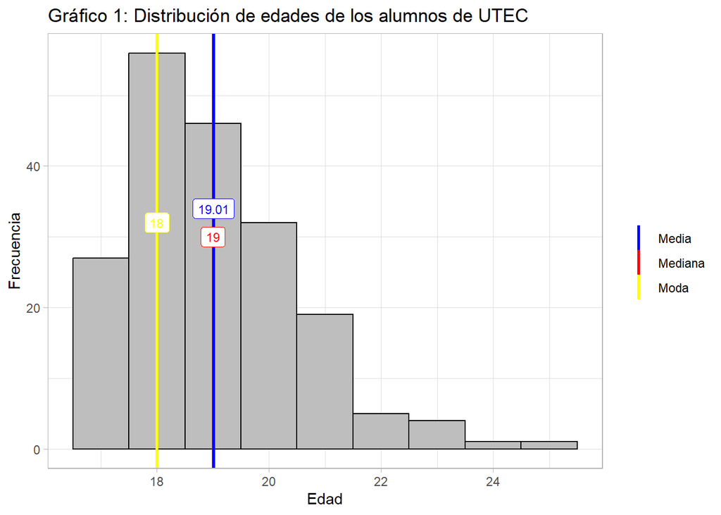

```r
ggplot(DD, aes(x=Edad)) +
  geom_histogram(binwidth=1, color="black", fill="gray") +
  geom_vline(aes(xintercept=median(Edad), color = "Mediana"), lwd=1) +
  geom_vline(aes(xintercept=mean(Edad), color = "Media"), lwd=1) +
  geom_vline(aes(xintercept=Mode(Edad), color = "Moda"), lwd=1) +
  labs(title="Gráfico 1: Distribución de edades de los alumnos de UTEC",x="Edad",y="Frecuencia") +
  scale_color_manual(name = " ", values = c(Mediana="red", Media ="blue", Moda ="yellow")) +
  theme_light() +
  geom_label(aes(x=mean(Edad), y=34, label=round(mean(Edad),digits=3)), fill="white", size=3, col="blue") +
  geom_label(aes(x=median(Edad), y=30, label=round(median(Edad),digits=3)), fill="white", size=3, col="red") + geom_label(aes(x=Mode(Edad), y=32, label=round(Mode(Edad),digits=3)), fill="white", size=3, col="yellow")
```

Podemos entender del siguiente gráfico 1 que hay una moda pronunciada de 18 años respecto a las demás edades. Es un histograma sesgado a la derecha, tiene una cola pronuncia hacia la derecha y una moda menor a la media y mediana respectivamente.

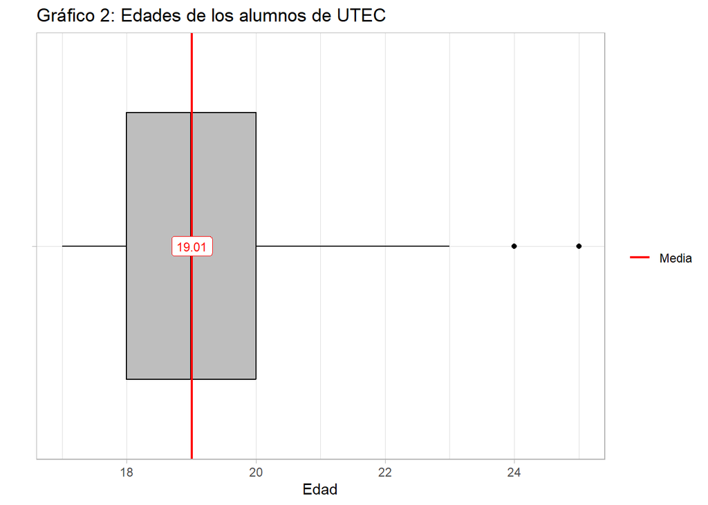

```r
ggplot(DD,aes(x=" ",y=Edad)) +
  geom_boxplot(color="black", fill="gray") +
  geom_hline(aes(yintercept=mean(Edad), color = "Media"), lwd=0.75) +
  scale_color_manual(name = " ", values = c(Media ="red")) +
  labs(title="Gráfico 2: Edades de los alumnos de UTEC",x="",y="Edad") +
  theme_light() + coord_flip() +
  geom_label(aes(x=1, y=mean(Edad), label=round(mean(Edad),digits=3)), fill="white", size=3, col="red")
```

En este boxplot podemos visualizar una concentración de las edades entre 18 y 20 años en conjunto con una mediana de 19 años. Y más de un dato atipico, aproximadamente 2 afuera del rango.

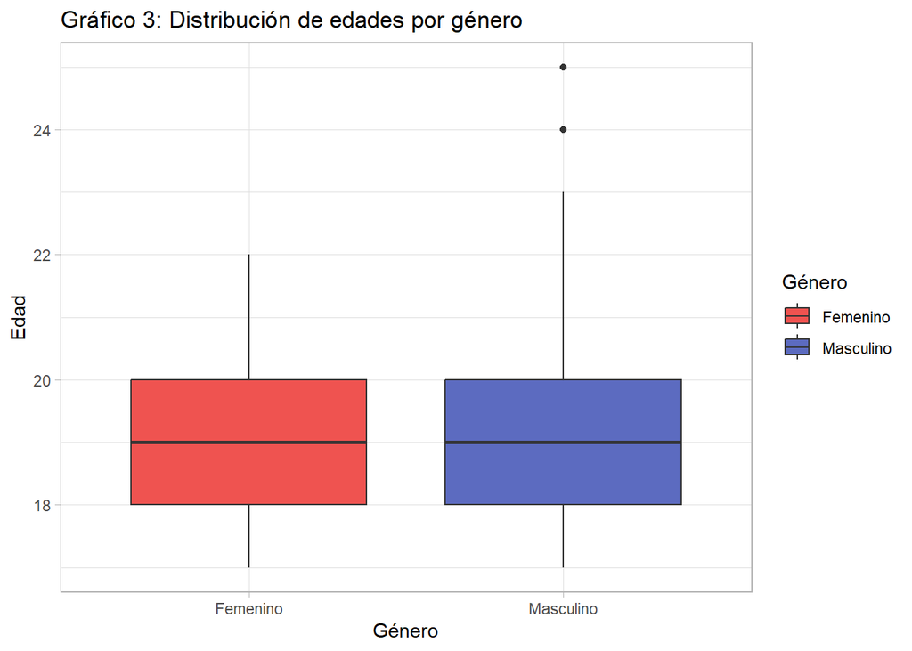

```r
ggplot(DD,aes(x=Genero,y=Edad, fill=Genero)) +
  geom_boxplot() +
  scale_fill_manual(values=c("#EF5350", "#5C6BC0")) +
  labs(title="Gráfico 3: Distribución de edades por género",x="Género",y="Edad", fill="Género") +
  theme_light()
```

Con la ayuda del summary podemos ver la distribución de edades desagregada por la variable género. El rango intercuartilico están entre las edades de 18 a 20 ya que ahí se concentra la mayoría de datos recogidos.

```r
table(DD$Edad,DD$Genero)
```

```
##
##      Femenino Masculino
##   17        6        21
##   18       25        31
##   19       16        30
##   20        8        24
##   21        5        14
##   22        4         1
##   23        0         4
##   24        0         1
##   25        0         1
```

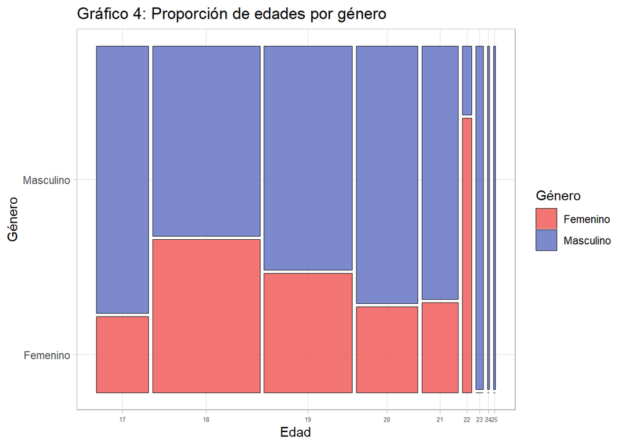

```r
ggplot(DD) +
  geom_mosaic(aes(x=product(Genero, Edad), fill=Genero, size = 1), color="black") +
  scale_fill_manual(values=c("#EF5350", "#5C6BC0")) +
  labs(title="Gráfico 4: Proporción de edades por género",x="Edad",y="Género", fill="Género") +
  theme_light() +
  theme(axis.text.x=element_text(size=5))
```

En este gráfico de mosaico podemos observar que los datos obtenidos mayormente son del género masculino que del femenino, y también podemos ver que la mayoría tiene 18 años.

## Análisis de la variable carreras

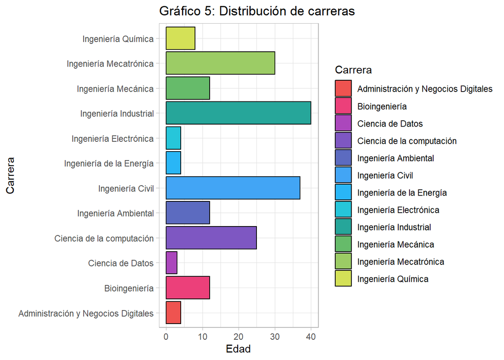

```r
ggplot(DD,aes(x=Carrera, fill=Carrera)) +
  geom_bar(color="black") +
  scale_fill_manual(values=c("#EF5350", "#EC407A", "#AB47BC", "#7E57C2", "#5C6BC0", "#42A5F5", "#29B6F6", "#26C6DA", "#26A69A", "#66BB6A", "#9CCC65", "#D4E157")) +
  labs(title="Gráfico 5: Distribución de carreras",x="Carrera",y="Edad") +
  theme_light() + coord_flip()
```

En este gráfico podemos ver la gran cantidad de encuestados pertenecientes a ingeniería industrial e ingeniería civil, siendo estos dos con más cantidad de alumnos. Y las que tienen menos son las carreras de ingeniería electrónica, ciencia de datos y energía.

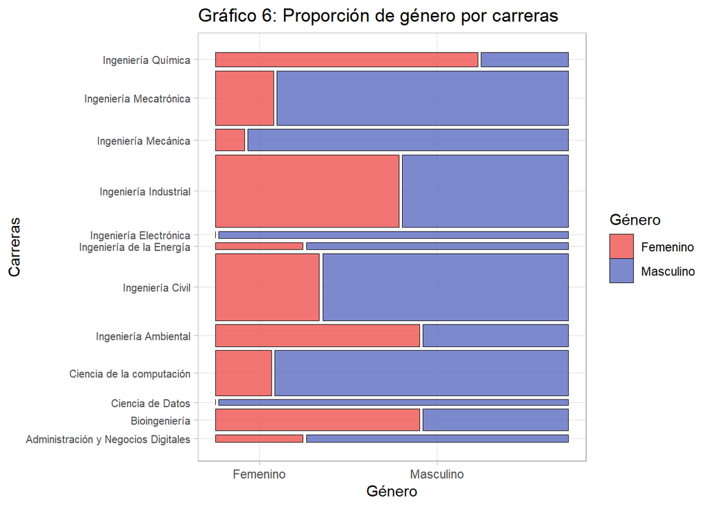

```r
ggplot(DD) +
  geom_mosaic(aes(x=product(Genero, Carrera), fill=Genero, size = 1), color="black") +
  scale_fill_manual(values=c("#EF5350", "#5C6BC0")) +
  labs(title="Gráfico 6: Proporción de género por carreras",x="Carreras",y="Género", fill="Género") +
  theme_light() + coord_flip() +
  theme(axis.text.y=element_text(size=7.5))
```

Como se pudo observar en un gráfico anterior de mosaico, los datos obtenidos son mayormente de hombres,aquí podemos ver a más detalle que los datos más obtenidos son de la carrera de Ing. Industrial e Ing. Civil. Además, la carrera que tienen más alumnado del género femenino es Ing. Química, como también las carreras que tienen menor alumnado del género femenino es Ing. Electrónica y la carrera de Ciencia de datos.

## Análisis de la variable Cursos

```r
summary(DD$Cursos)
```

```
##    Min. 1st Qu.  Median    Mean 3rd Qu.    Max.
##   3.000   5.000   6.000   5.791   6.000   8.000
```

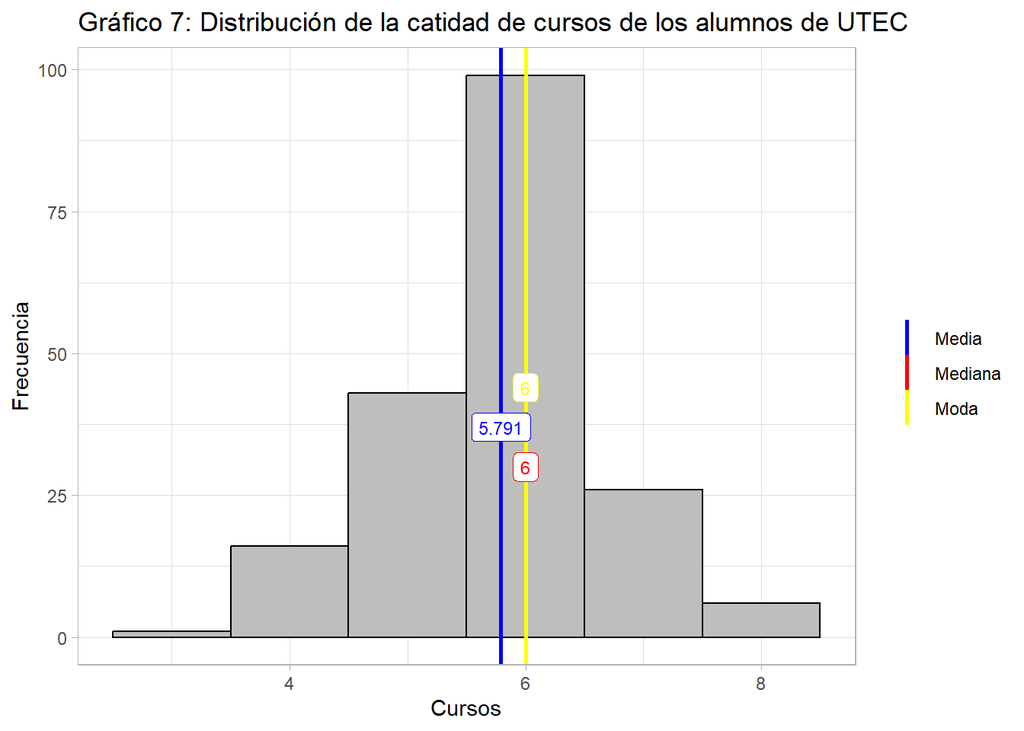

```r
ggplot(DD, aes(x=Cursos)) +
  geom_histogram(binwidth=1, color="black", fill="gray") +
  geom_vline(aes(xintercept=median(Cursos), color = "Mediana"), lwd=1) +
  geom_vline(aes(xintercept=mean(Cursos), color = "Media"), lwd=1) +
  geom_vline(aes(xintercept=Mode(Cursos), color = "Moda"), lwd=1) +
  labs(title="Gráfico 7: Distribución de la catidad de cursos de los alumnos de UTEC",x="Cursos",y="Frecuencia",color="Legend") +
  scale_color_manual(name = " ", values = c(Mediana="red", Media ="blue", Moda ="yellow")) +
  theme_light() +
  geom_label(aes(x=mean(Cursos), y=37, label=round(mean(Cursos),digits=3)), fill="white", size=3, col="blue") + geom_label(aes(x=median(Cursos), y=30, label=round(median(Cursos),digits=3)), fill="white", size=3, col="red") +
  geom_label(aes(x=Mode(Cursos), y=44, label=round(Mode(Cursos),digits=3)), fill="white", size=3, col="yellow")
```

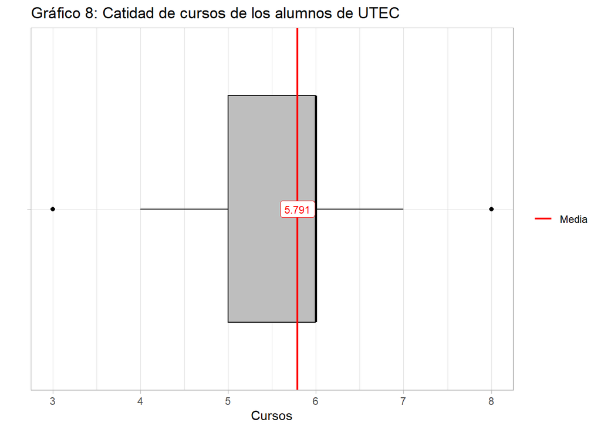

```r
ggplot(DD,aes(x=" ",y=Cursos)) +
  geom_boxplot(color="black", fill="gray") +
  geom_hline(aes(yintercept=mean(Cursos), color = "Media"), lwd=0.75) +
  scale_color_manual(name = " ", values = c(Media ="red")) +
  labs(title="Gráfico 8: Catidad de cursos de los alumnos de UTEC",x="",y="Cursos") +
  theme_light() + coord_flip() +
  geom_label(aes(x=1, y=mean(Cursos), label=round(mean(Cursos),digits=3)), fill="white", size=3, col="red")
```

En este boxplot podemos observar una concentración de las cantidades de cursos entre 5 y 6 cursos en conjunto con una media de 5.8. Y más de un dato atipico, aproximadamente 2 afuera del rango.

## Análisis de la variable Ansiedad

### Análisis respecto a la variable Anxiety_before_ex

La ansiedad antes de exámenes está siempre ya que tienes que rendir una prueba importante o una exposición importante que vale gran parte de tu nota final. Por eso algunos alumnos tienden a ansiarse demasiado antes de rendir dicha prueba.

#### Gráficos de la variable

```r
summary(DD$anxiety_before_ex)
```

```
##    Min. 1st Qu.  Median    Mean 3rd Qu.    Max.
##   1.000   6.000   8.000   7.293   9.000  10.000
```

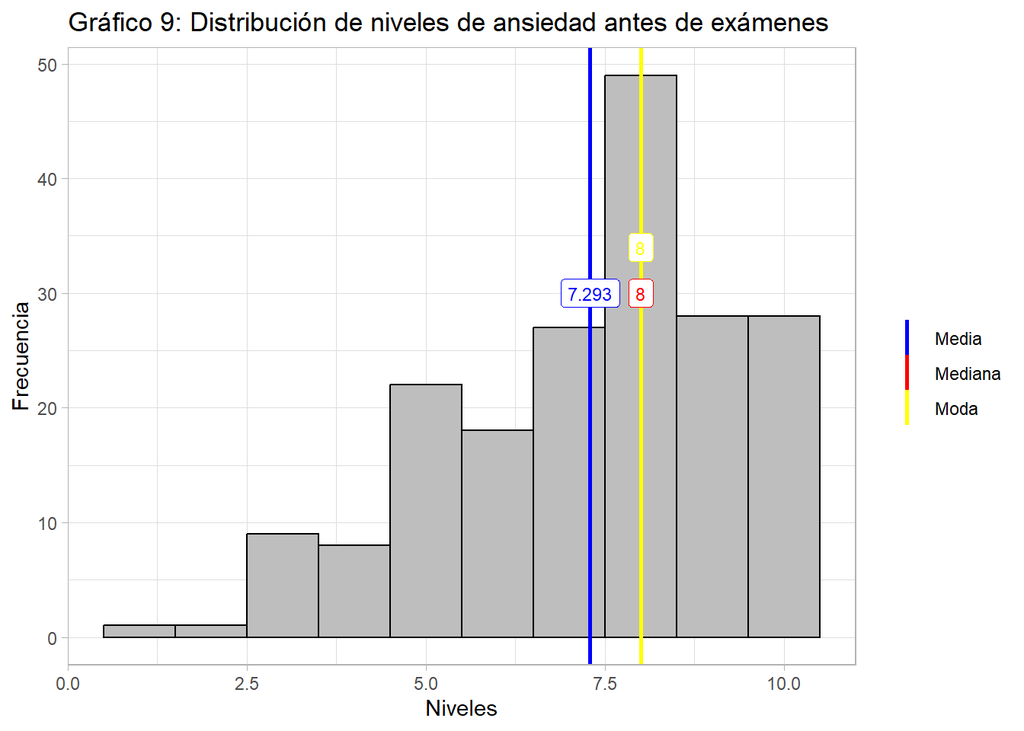

```r
ggplot(DD, aes(x=anxiety_before_ex)) +
  geom_histogram(binwidth=1, color="black", fill="gray") +
  geom_vline(aes(xintercept=median(anxiety_before_ex), color = "Mediana"), lwd=1) +
  geom_vline(aes(xintercept=mean(anxiety_before_ex), color = "Media"), lwd=1) +
  geom_vline(aes(xintercept=Mode(anxiety_before_ex), color = "Moda"), lwd=1) +
  labs(title="Gráfico 9: Distribución de niveles de ansiedad antes de exámenes",x="Niveles",y="Frecuencia",color="Legend") +
  scale_color_manual(name = " ", values = c(Mediana="red", Media ="blue", Moda ="yellow")) +
  theme_light() +
  geom_label(aes(x=mean(anxiety_before_ex), y=30, label=round(mean(anxiety_before_ex),digits=3)), fill="white", size=3, col="blue") +
  geom_label(aes(x=median(anxiety_before_ex), y=30, label=round(median(anxiety_before_ex),digits=3)), fill="white", size=3, col="red") +
  geom_label(aes(x=Mode(anxiety_before_ex), y=34, label=round(Mode(anxiety_before_ex),digits=3)), fill="white", size=3, col="yellow")
```

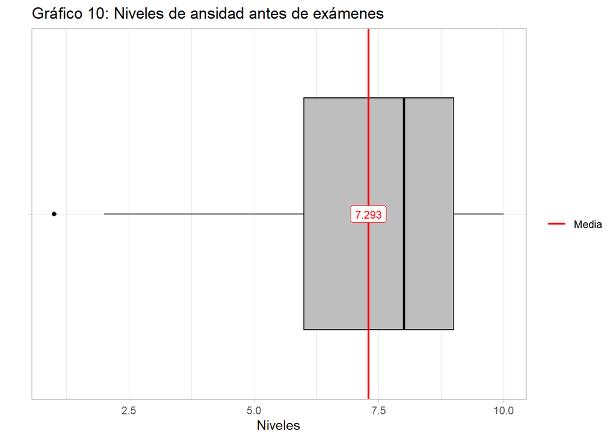

```r
ggplot(DD,aes(x=" ",y=anxiety_before_ex)) +
  geom_boxplot(color="black", fill="gray") +
  geom_hline(aes(yintercept=mean(anxiety_before_ex), color = "Media"), lwd=0.75) +
  scale_color_manual(name = " ", values = c(Media ="red")) +
  labs(title="Gráfico 10: Niveles de ansidad antes de exámenes",x="",y="Niveles") +
  theme_light() + coord_flip() +
  geom_label(aes(x=1, y=mean(anxiety_before_ex), label=round(mean(anxiety_before_ex),digits=3)), fill="white", size=3, col="red")
```

Mediante este boxplot podemos tener otra vista de los grandes niveles que tienen los alumnos antes de dar un examen. Teniendo una media de 7.3. Y una moda mayor a esta con un valor de 8

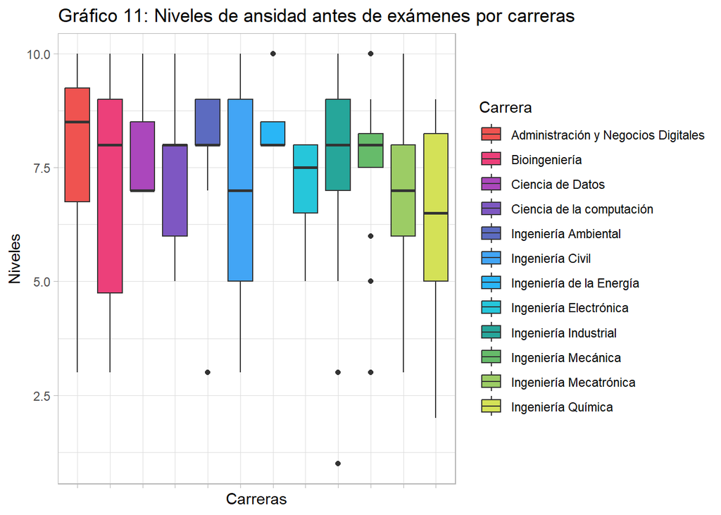

```r
ggplot(DD,aes(x=Carrera,y=anxiety_before_ex, fill=Carrera)) +
  geom_boxplot() +
  scale_fill_manual(values=c("#EF5350", "#EC407A", "#AB47BC", "#7E57C2", "#5C6BC0", "#42A5F5", "#29B6F6", "#26C6DA", "#26A69A", "#66BB6A", "#9CCC65", "#D4E157")) +
  labs(title="Gráfico 11: Niveles de ansidad antes de exámenes por carreras",x="Carreras",y="Niveles") +
  theme_light() +
  theme(axis.text.x=element_blank())
```

En este caso podemos visualizar la cantidad de ansiedad pero desagragada por carreras y vemos en donde se concentra una mayor y una menor ansiedad.

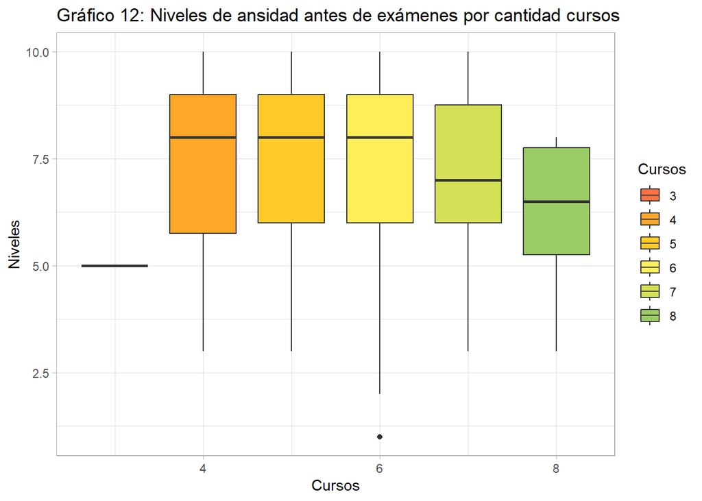

```r
ggplot(DD,aes(x=Cursos,y=anxiety_before_ex, fill=factor(Cursos), group=interaction(Cursos))) +
  geom_boxplot() +
  scale_fill_manual(values=c("#FF7043", "#FFA726", "#FFCA28", "#FFEE58", "#D4E157", "#9CCC65")) +
  labs(title="Gráfico 12: Niveles de ansidad antes de exámenes por cantidad cursos",x="Cursos",y="Niveles", fill="Cursos") +
  theme_light()
```

Se puede observar que las distribuciones de las escalas de ansiedad son muy parecidas. Si se intenta hacer un diagrama de dispersión, el resultado no es muy claro, debido a la superposición de puntos.

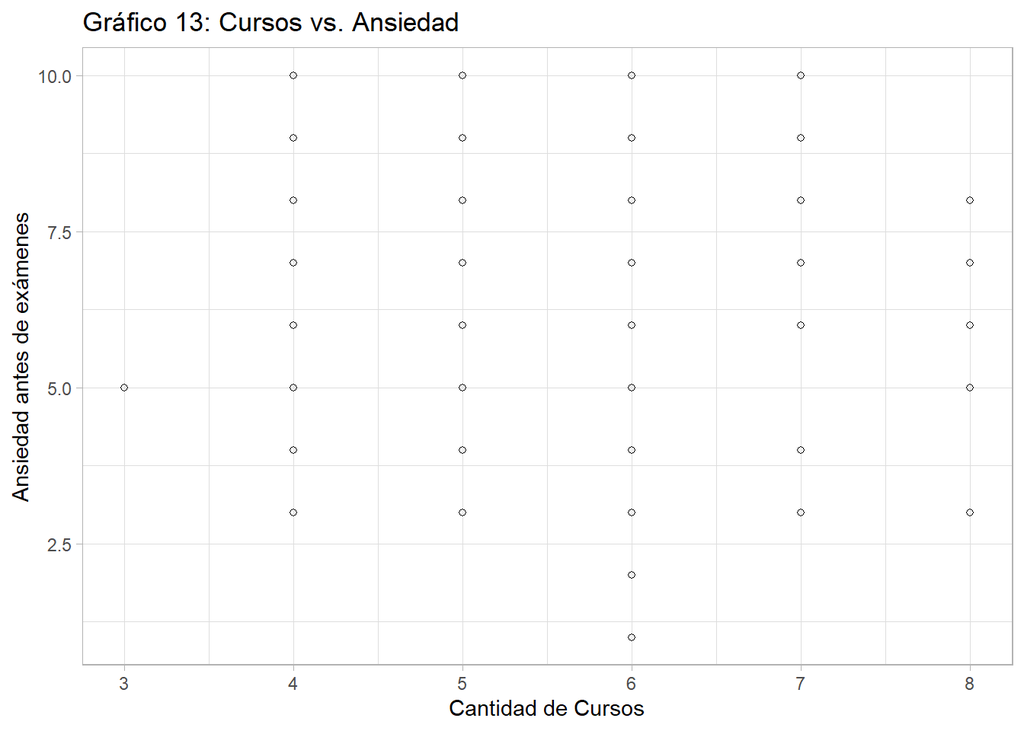

```r
ggplot(DD,aes(x=Cursos,y=anxiety_before_ex)) +
  geom_point(shape=1) +
  labs(title="Gráfico 13: Cursos vs. Ansiedad",x="Cantidad de Cursos",y="Ansiedad antes de exámenes") +
  theme_light()
```

Se puede observar que hay al menos un estudiante cuya cantidad de cursos es 3, esto debido a la superposición de puntos.

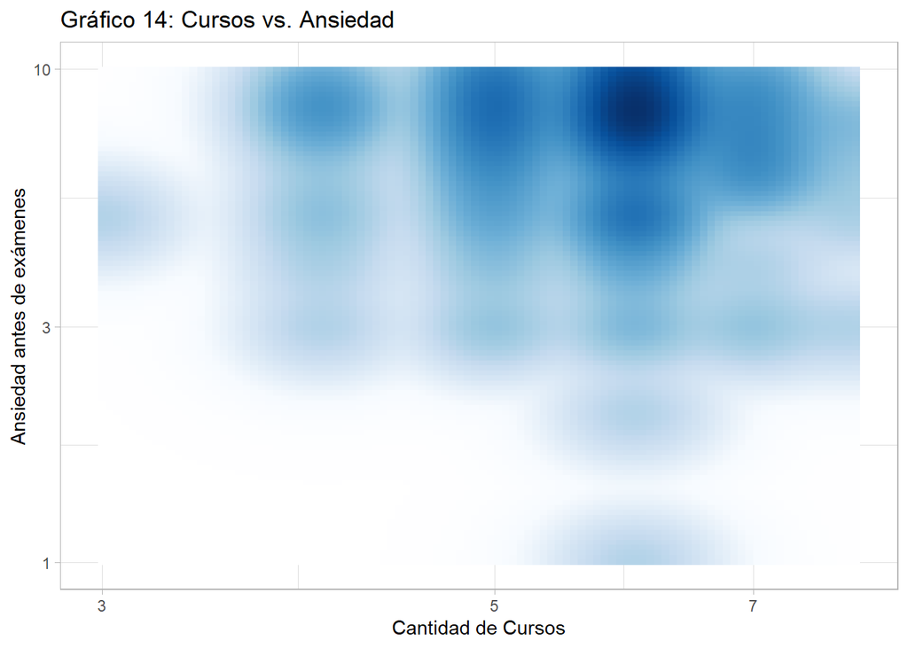

```r
ggplot(DD) + aes(x=Cursos, y=anxiety_before_ex) + scale_x_log10() + scale_y_log10() +
  stat_density2d(geom="tile", aes(fill=..density..^0.25, alpha=1), contour=FALSE) +
  geom_point(size=0.5) +
  stat_density2d(geom="tile", aes(fill=..density..^0.25,     alpha=ifelse(..density..^0.25<0.4,0,1)), contour=FALSE) +
  scale_fill_gradientn(colours = colorRampPalette(c("white", blues9))(256)) +
  labs(title="Gráfico 14: Cursos vs. Ansiedad",x="Cantidad de Cursos",y="Ansiedad antes de exámenes") +
  theme_light() + theme(legend.position = "none")
```

A comparación del gráfico anterior, se puede observar mejor qué puntos se superponen. Este gráfico desenfatiza las observaciones individuales, trabajando con colores más oscuros o más claros para los casos donde haya más o menos observaciones respectivamente.

#### Regresión Lineal Anxiety_before_ex respecto a Cantidad de cursos

```r
Mod1 = lm(DD$anxiety_before_ex~DD$Cursos)
summary(Mod1)
```

```
##
## Call:
## lm(formula = DD$anxiety_before_ex ~ DD$Cursos)
##
## Residuals:
##     Min      1Q  Median      3Q     Max
## -6.2742 -1.2742  0.6352  1.6352  2.8163
##
## Coefficients:
##             Estimate Std. Error t value Pr(>|t|)
## (Intercept)  7.81751    0.94739   8.252 2.62e-14 ***
## DD$Cursos   -0.09055    0.16163  -0.560    0.576
## ---
## Signif. codes:  0 '***' 0.001 '**' 0.01 '*' 0.05 '.' 0.1 ' ' 1
##
## Residual standard error: 2.029 on 189 degrees of freedom
## Multiple R-squared:  0.001658,   Adjusted R-squared:  -0.003625
## F-statistic: 0.3138 on 1 and 189 DF,  p-value: 0.576
```

De dónde podemos obetener la siguiente ecuación: Ansiedad Pre = 7.81751 - 0.09055 * Cursos No obstante nuestro R^2 es de 0.001658 cuando lo ideal es que sea de 0.6 o más, por lo tanto este modelo no es nada confiable

```r
AnsiedadPre1 <- 7.81751 - 0.09055 * DD$Cursos
```

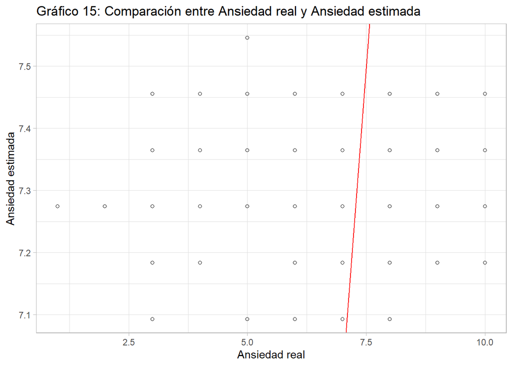

```r
ggplot(DD,aes(x=anxiety_before_ex,y=AnsiedadPre1)) +
  geom_point(shape=1) +
  labs(title="Gráfico 15: Comparación entre Ansiedad real y Ansiedad estimada",x="Ansiedad real",y="Ansiedad estimada") +
  theme_light() +
  geom_abline(intercept=0, slope=1, col="red")
```

### Análisis Anxiety_after_ex

Por otro lado las ansiedad después de exámenes nos dice que podría ser un nivel menor comparada al antes, ya que ya rendiste tu prueba y puedes estar más tranquilo.